# Posterior Sampling

Frank Edwards

## Sampling from the posterior

- We use Bayesian methods to *approximate* the posterior distribution
- We can then sample parameters from the estimated posterior to learn about parameters or to simulate predictions
- We can plot densities, directly sample *credible intervals*, compare differences in means, all without relying on a theoretical *sampling distribution*, like we do with frequentist methods

## Summarizing distributions

Let’s say we want to know how much probability mass there is within $\pm 1.4$ standard deviations of 0 for $x \sim N(0,1)$.

The Normal probability density function (PDF) is:

$$\frac{1}{\sigma\sqrt{2\pi}} e^{-\frac{1}{2}\left(\frac{x - \mu}{\sigma}\right)^2}$$

## Integrals are hard

To answer our question exactly, we can take the integral of the PDF from $-1.4$ to $1.4$:

$$\int_{-1.4}^{1.4} \frac{1}{\sigma\sqrt{2\pi}} e^{-\frac{1}{2}\left(\frac{x - \mu}{\sigma}\right)^2} dx$$

- I don’t want to do this, and I suspect neither do you.
- *Note:* We can just use dnorm() here, but most of our posteriors won’t be so simple to work with.

## But simulation is easy!

1. Sample from the target distribution

```r
n_samples<-10000
samples<-rnorm(n = n_samples, mean = 0, sd = 1)
```

2. Summarize our quantity of interest

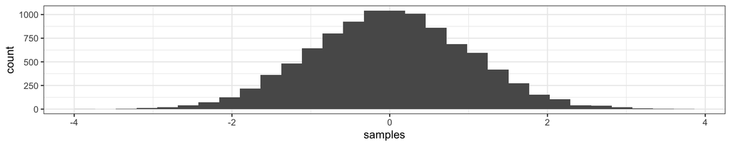

```r
ggplot(data.frame(samples), aes(x=samples)) + geom_histogram()
```

## Using samples to calculate quantities of interest

- What are the mean and SD of this paramter?

```r
mean(samples)
```

```
[1] -1.674023e-05
```

```r
sd(samples)
```

```
[1] 0.9996785
```

- How much mass is within $0 \pm 1.4 \sigma$?

```r
samples_df<-data.frame(samples)
samples_df  |>
  filter(samples>=-1.4 & samples<=1.4) |>
  summarise(mass = n()/n_samples)
```

```
    mass
1 0.8377
```

## Estimation strategies

- For products of probability distributions (*ie* $prior \times likelihood$); there usually aren’t exact solutions.
- We’ll rely on 3 algorithms to *approximate* posterior distributions to condition the prior on the likelihood of the data.

## Our approximation engines

- Grid approximation (check!)
- Quadratic approximation (today!)
- Markov Chain Monte Carlo (MCMC) (week 9 on, with some in week 5/6)

## Grid approximation algorithm

1. Define the grid
2. Compute the prior for each parameter value on the grid
3. Compute the likelihood for each parameter value on the grid
4. Multiply the prior by the likelihood
5. Divide by the sum of all values

## Grid approximation in R

We draw (with replacement) six green marbles from a bag that we know has red and green marbles; we want to know the proportion green ($p$) in the bag.

```r
### size of grid
length <- 50
### make our grid
grid<-seq(from = 0, to = 1, length.out = length)
### uniform (flat) prior
prior  <-  rep(1, length)
### likelihood, observe 6 of 9 green, how likely under each value of p?
likelihood  <-  dbinom(6, size = 9, prob = grid)
### update the posterior
posterior <- prior * likelihood / sum(prior * likelihood)
```

## Sampling from a grid-estimated posterior

- We’ve estimated the posterior probability density for each value on the grid
- We can draw random samples from this distribution.
- With a large enough number of samples, we can closely approximate the distribution
- Using these samples, we can learn alot about the parameter of interest

## Draw samples of proportion water from grid estimated posterior

```r
post_samples<-sample(
  grid,
  prob = posterior,
  size = 10,
  replace = T)

round(post_samples,2)
```

```
 [1] 0.67 0.65 0.55 0.55 0.47 0.73 0.57 0.27 0.69 0.43
```

## Our estimate of *p*, 10 posterior draws

```r
plot_dat<-data.frame(
  post_samples = sample(
      grid,
      prob = posterior,
      size = 10,
      replace = T))

ggplot(plot_dat,
       aes(x = post_samples)) +
  geom_density() +
  coord_cartesian(xlim=c(0,1))
```

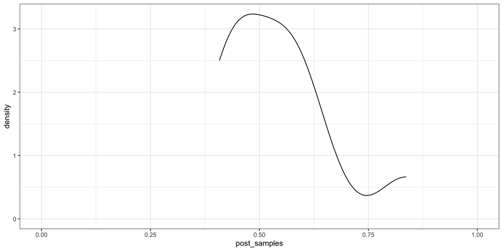

## 100 posterior draws

```r
plot_dat<-data.frame(
  post_samples = sample(
      grid,
      prob = posterior,
      size = 100,
      replace = T))

ggplot(plot_dat,
       aes(x = post_samples)) +
  geom_density() +
  coord_cartesian(xlim=c(0,1))
```

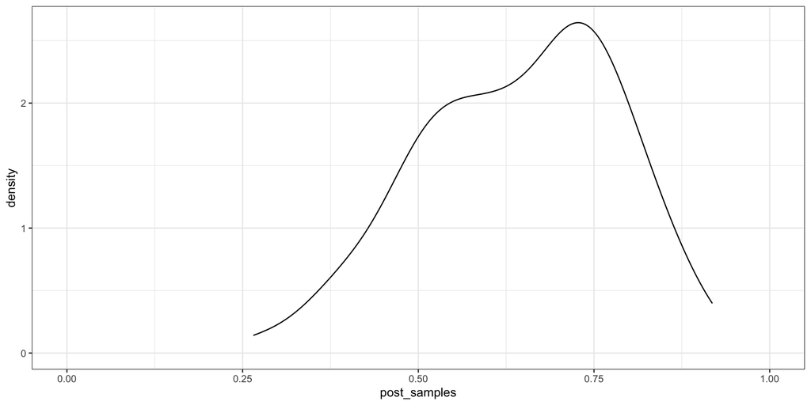

## 1000 draws

```r
plot_dat<-data.frame(
  post_samples = sample(
      grid,
      prob = posterior,
      size = 1000,
      replace = T))

ggplot(plot_dat,
       aes(x = post_samples)) +
  geom_density() +
  coord_cartesian(xlim=c(0,1))
```

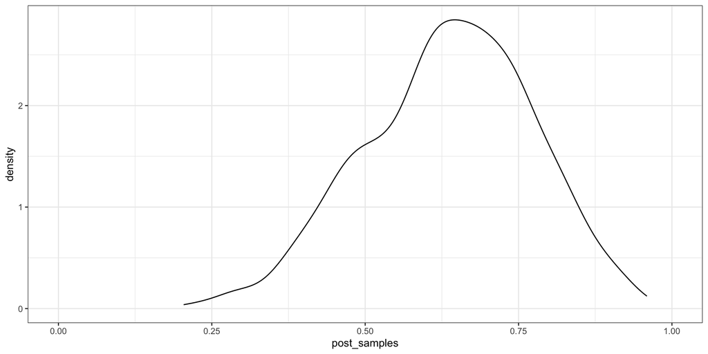

## 10000 draws

```r
plot_dat<-data.frame(
  post_samples = sample(
      grid,
      prob = posterior,
      size = 10000,
      replace = T))

ggplot(plot_dat,
       aes(x = post_samples)) +
  geom_density() +
  coord_cartesian(xlim=c(0,1))
```

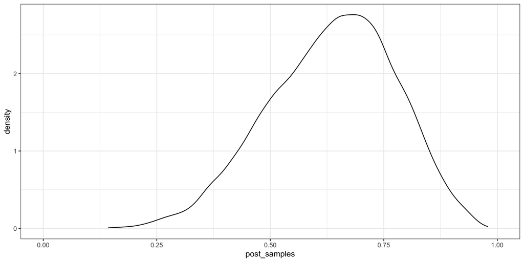

## 100000 draws

```r
plot_dat<-data.frame(
  post_samples = sample(
      grid,
      prob = posterior,
      size = 100000,
      replace = T))

ggplot(plot_dat,
       aes(x = post_samples)) +
  geom_density() +
  coord_cartesian(xlim=c(0,1))
```

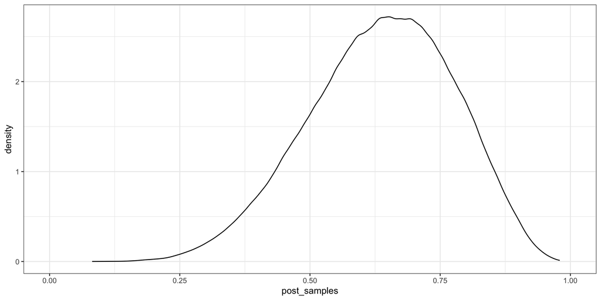

## So what now?

What questions do we typically ask about a parameter?

- What is the mean / expected value of the parameter?
- How certain are we about the location of the parameter?

## Using posterior samples

- What is $E(p)$

```r
mean(plot_dat$post_samples)
```

```
[1] 0.6367445
```

- How certain are we about the location of $p$? Where is 92 percent of the posterior probability?

```r
quantile(plot_dat$post_samples, c(0.04, 0.96))
```

```
       4%       96%
0.3877551 0.8571429
```

- Conditional on the data and our assumptions (priors, likelihood), we can describe the posterior *without* appealing to theoretical replications (!!!)

## Exact binomial likelihood

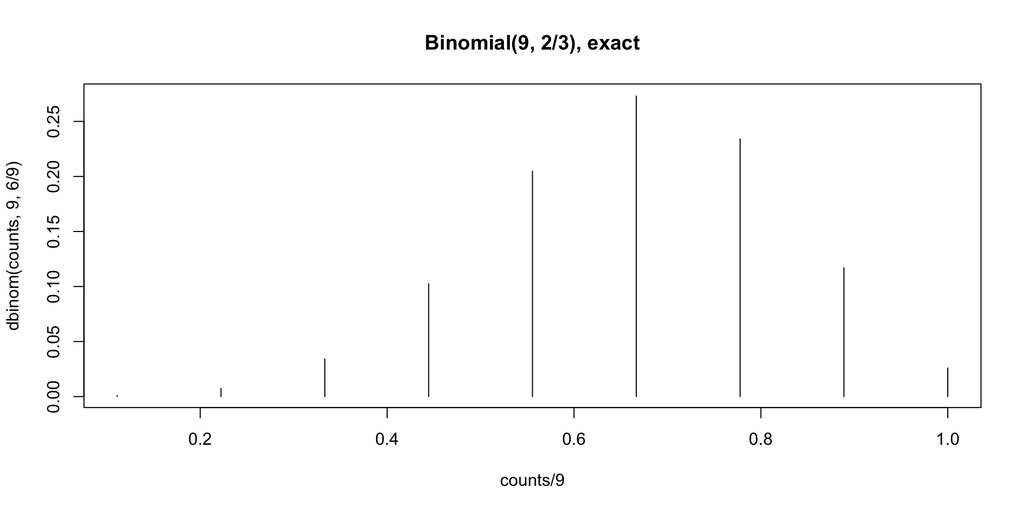

## Posterior approximation

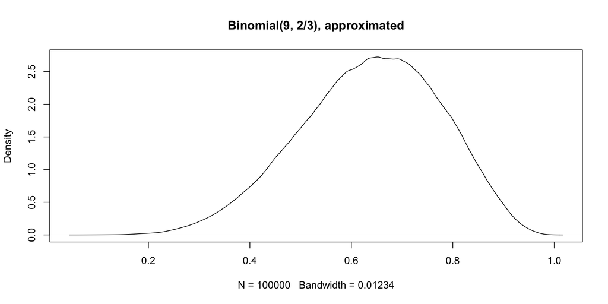

## Quadratic approximation

1. Assume our posterior is approximately Normal (often reasonable)
2. Find the mode
3. Estimate curvature of the log posterior with a parabola
4. Use the resulting Gaussian distribution for inference
5. With enough data: $\textsf{quap} \rightarrow \textsf{MLE}$

## Using quadratic approximation in R

```r
### First, define the data as a list() object
### let's treat 1 as green, 0 as red
dat<-list(G = 6, R = 3)
```

## Using quadratic approximation in R

```r
## Specify the prior and likelihood in alist() object
formula_list<-alist(
  # likelihood
  G ~ dbinom(R+G, p),
  # prior
  p ~ dunif(0,1)
)
```

## Using quadratic approximation in R

```r
model1<-quap(
  formula_list,
  data = dat
)
```

## Using quadratic approximation in R

```r
# summarize the distribution using summary() or precis()
summary(model1)
```

```
       mean        sd      5.5%     94.5%
p 0.6666667 0.1571338 0.4155366 0.9177968
```

## Extract posterior samples

```r
post_samples<-extract.samples(model1, n=10000)
```

## Visualize

```r
p1<-ggplot(post_samples, aes(y = p, x = 1:nrow(post_samples))) +
  geom_point(alpha = 0.1)
p2<-ggplot(post_samples, aes(x = p)) +
  geom_density()
### grid.arrange() lets us put more than one plot in a window
grid.arrange(p1, p2, ncol = 2)
```

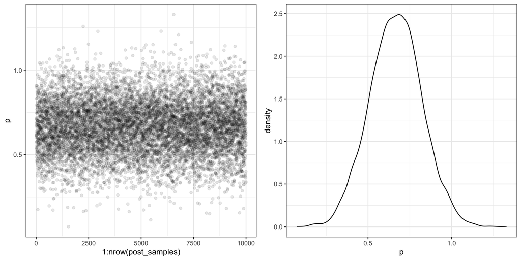

## Using this object

```r
### peek inside
head(post_samples)
```

```
          p
1 0.6369756
2 0.5745009
3 0.6673372
4 0.5324838
5 0.9078291
6 0.6811012
```

## Learning from the posterior

Questions we can ask with posterior samples:

- How much posterior probability lies (below/above/between) some parameter value(s)?
- Which parameter values mark the (lower/upper) n% of the posterior probability?
- Which parameter value has the highest posterior probability?

## Probability above/below

- We can simply filter the samples, then divide by the size of the posterior sample.
- **Q:** What is the posterior probability that the bag is less than 60 percent green, conditional on our model and the data (6G, 3R)?

```r
post_samples |>
  filter(p<0.6) |>
  summarise(p = n()/nrow(post_samples))
```

```
       p
1 0.3358
```

## Probability above/below

- **Q:** What is the posterior probability that there is between 60 percent and 90 percent green marbles in the bag, conditional on our model and the data?

```r
post_samples |>
  filter(p>=0.6 & p<=0.9) |>
  summarise(p = n()/nrow(post_samples))
```

```
      p
1 0.599
```

## Confidence (posterior) intervals

- **Q:** Where does 90% of the posterior probability mass lie?

```r
quantile(post_samples$p, c(0.05, 0.95))
```

```
       5%       95%
0.4062213 0.9219134
```

```r
quantile(post_samples$p, 0.9)
```

```
      90%
0.8641941
```

- Thoughts on the differences between these two intervals?

## Posterior intervals

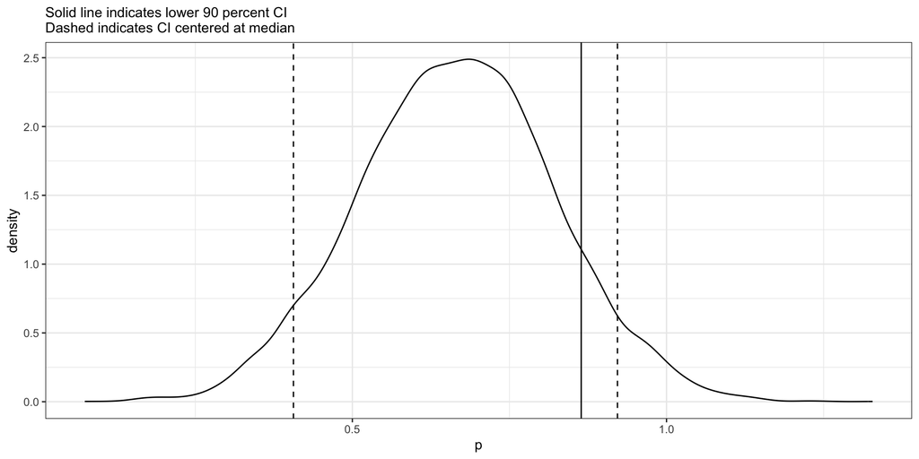

## Confidence intervals versus Bayesian intervals

- Confidence interval: If we replicated the experiment many times, the true value would lie within this interval 90 percent of the time.
- Posterior interval: Conditional on our data and model (priors, likelihood), 90 percent of compatible parameter values lie within this range.

## Point estimates

- Which parameter value has the highest posterior probability?

```r
chainmode(post_samples$p, adj = 0.01)
```

```
[1] 0.7268666
```

- This is the maximum a posteriori (MAP) estimate.
- If our posterior is approximately symmetric, the MAP and median will be similar

```r
median(post_samples$p)
```

```
[1] 0.6668776
```

## Simulating prediction

- We’ve learned how to describe the parameter *p* with posterior samples.
- What would happen if we re-ran the experiment?
- **Posterior predictive simulation** incorporates updated information on the parameter into predictions of new values of our observed outcome variable (W, L)

## Posterior prediction algorithm

1. Sample from the posterior distribution
2. Use these sampled posterior parameter values to sample new values from the likelihood

## Posterior prediction in R

```r
# Draw samples of posterior p from model1
# Truncate impossible p >1 (Gaussian has long tails)
p_samples<-extract.samples(model1) |>
  mutate(p = ifelse(p>1, 1, p))
## sample from likelihood
RG_predictions<-rbinom(1e4, size = 9, prob = p_samples$p)
## distribution of predictions of G under our posterior
table(RG_predictions)
```

```
RG_predictions
   0    1    2    3    4    5    6    7    8    9
  26  125  312  670 1123 1589 1817 1880 1439 1019
```

## Visualize the predictions

```r
ggplot(data.frame(RG_predictions),
       aes(x = RG_predictions)) +
  geom_histogram() +
  scale_x_continuous(breaks=0:9) +
  labs(title = "Posterior predictions of W")
```

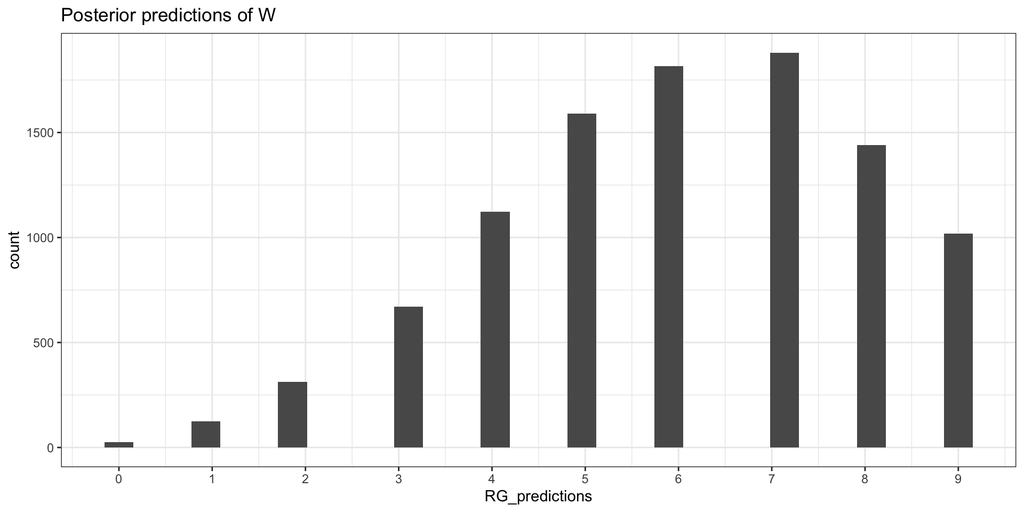

## The impact of uncertainty in p on predictions

```r
ggplot(p_samples, aes(x = p)) +
  geom_histogram()
```

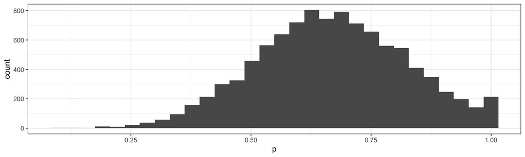

## p = posterior median

```r
## set p at the median of the posterior
samples<-rbinom(1e4, 9, median(p_samples$p))
ggplot(data.frame(samples), aes(x = samples)) +
  geom_histogram()
```

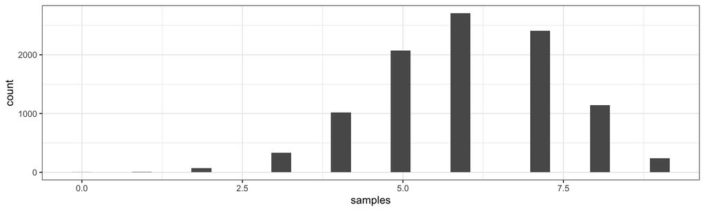

## p = posterior 5th percentile

```r
## set p at the 5th percentile of the posterior
samples<-rbinom(1e4, 9, quantile(p_samples$p, 0.05))
ggplot(data.frame(samples), aes(x = samples)) +
  geom_histogram()
```

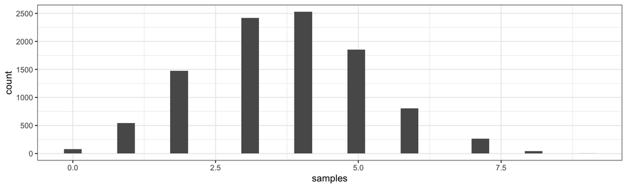

## p = posterior 95th percentile

```r
## set p at the 95th percentile of the posterior
samples<-rbinom(1e4, 9, quantile(p_samples$p, 0.95))
ggplot(data.frame(samples), aes(x = samples)) +
  geom_histogram()
```

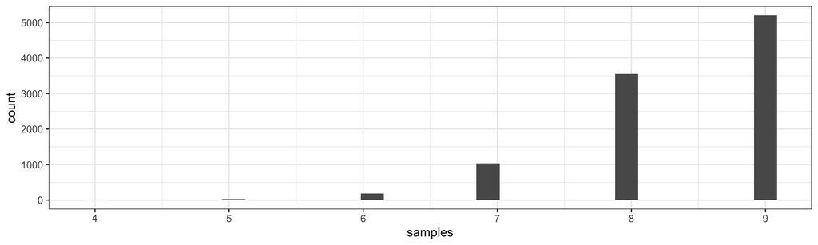

## Propagating ALL uncertainty

**Posterior predictive distributions propagate uncertainty in p into predictions**

```r
ggplot(data.frame(RG_predictions),
       aes(x = RG_predictions)) +
  geom_histogram() +
  scale_x_continuous(breaks=0:9) +
  labs(title = "Posterior predictions of G")
```

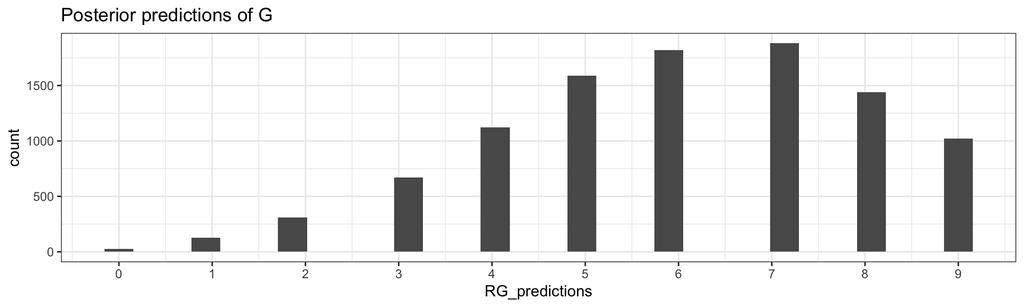

## Prior prediction

We can also use simulation to better understand and select priors

```r
### our prior
formula_list
```

```
[[1]]
G ~ dbinom(R + G, p)

[[2]]
p ~ dunif(0, 1)
```

```r
prior_samples<-runif(1e4, 0, 1)

head(prior_samples)
```

```
[1] 0.5836418 0.2305983 0.5799636 0.7134089 0.8438489 0.3605211
```

## Visualize the prior predictions

```r
ggplot(data.frame(prior_samples),
       aes(x = prior_samples)) +
  coord_cartesian(xlim = c(0, 1)) +
  geom_histogram(bins = 20)
```

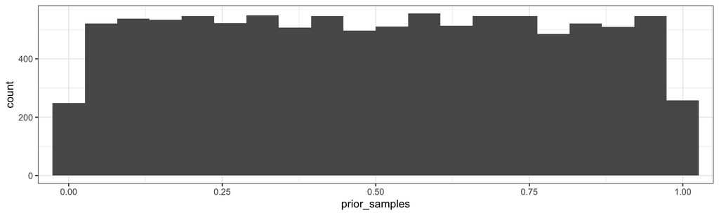

## Summary

- Simulation is a fundamental tool in Bayesian data analysis
- Visualize samples from the prior, posterior, and posterior predictive distributions
- Posterior prediction far more informative than point estimate / std. error approach